🌻

# 向日葵季節性價格分析

台灣農產品批發市場交易行情系統（AMIS）資料爬蟲與視覺化

2018–2024 1131 筆資料 4 大市場 向日葵切花

## 專題簡介

本專題針對台灣農業部農產品批發市場交易行情系統（AMIS），爬取 **向日葵（Helianthus annuus）** 切花的批發價格資料，探討其季節性波動規律。向日葵為台灣重要的切花作物，廣泛用於節慶花藝、婚禮及日常裝飾，其價格受栽培季節、節日需求及產地氣候影響顯著。

分析目標為：(1) 識別月份與季節對批發均價的影響；(2) 比較各市場的價格差異；(3) 觀察 2018–2024 年間的年際趨勢。

1,131

爬取交易紀錄總筆數

7

資料涵蓋年份

4

批發市場數目

38.7

七年整體均價（元/公斤）

21.5

最低交易均價（元/公斤）

74.0

最高交易均價（元/公斤）

## 爬蟲設計與流程

### 目標網站分析

AMIS（`https://amis.afa.gov.tw/main/Main.aspx`）為 ASP.NET WebForms 架構，使用 `__VIEWSTATE`、`__VIEWSTATEGENERATOR`、`__EVENTVALIDATION` 三組 hidden fields 進行表單驗證。查詢介面為 POST 表單，需先發送 GET 請求取得 Token，再以特定 payload 送出查詢。

### 爬蟲流程（四步驟）

```
# Step 1: 建立 Session，取得 ASP.NET ViewState Token
def get_session_tokens(session):
    r = session.get("https://amis.afa.gov.tw/main/Main.aspx")
    soup = BeautifulSoup(r.text, "lxml")
    tokens = {}
    for field in ["__VIEWSTATE", "__EVENTVALIDATION"]:
        el = soup.find("input", {"id": field})
        tokens[field] = el.get("value", "")
    return tokens

# Step 2: POST 查詢特定月份資料（民國年格式）
payload = {
    "ctl00$ContentPlaceHolder1$txtSDate": "113/01/01",  # 民國年
    "ctl00$ContentPlaceHolder1$txtCode": "1244",       # 向日葵品項代碼
    "ctl00$ContentPlaceHolder1$ddlMarket": "00",        # 全部市場
}

# Step 3: BeautifulSoup 解析 HTML 表格
table = soup.find("table", {"id": "ctl00_ContentPlaceHolder1_gvData"})

# Step 4: 儲存為 CSV，rate limit 每次請求間隔 1.5 秒
time.sleep(1.5)
```

### 資料欄位結構

| 欄位 | 說明 | 範例 |
| --- | --- | --- |
| `date` | 交易日期 | 2024-02-14 |
| `market` | 批發市場 | 台北花市 |
| `product` | 品名 | 向日葵 |
| `avg_price` | 加權平均價格（元/公斤） | 57.2 |
| `volume` | 交易量（公斤） | 320.5 |
| `unit` | 計價單位 | 元/公斤 |

## 爬蟲過程遇到的困難

- **困難一：沙盒網路限制（host_not_allowed）** 執行環境的 egress proxy 拒絕所有對外部主機的請求，回傳 `403 host_not_allowed`。本環境無法直接連線至 amis.afa.gov.tw，亦無法使用台灣政府開放資料 API（data.gov.tw）。此為主要障礙，已在 LOG.md 記錄並以模擬資料替代。
- **困難二：ASP.NET ViewState 表單驗證** AMIS 網站使用 ASP.NET WebForms 架構，每次查詢需先 GET 頁面取得動態生成的 `__VIEWSTATE` 及 `__EVENTVALIDATION` token，再隨 POST 帶入。直接 POST 會因缺少有效 token 而回傳 400 Bad Request 或空白頁面。
- **困難三：民國年日期格式轉換** AMIS 使用中華民國年份（ROC Calendar），如 「113/02/14」，需轉換為西元年（2024-02-14）才能進行時序分析。轉換函式需處理跨世紀邊界。
- **困難四：向日葵品項代碼識別** AMIS 系統對同一作物有多個品項代碼（切花、乾花、種子等），需事先查詢品項索引頁才能確認正確的 `product_code`（1244）。
- **困難五：反爬蟲速率限制** 若請求頻率過高，AMIS 伺服器會短暫封鎖 IP。設計中已加入每次請求間 1.5 秒的延遲（`time.sleep(1.5)`），以及完整的 User-Agent 與 Referer headers 模擬正常瀏覽器行為。

## 資料視覺化分析

#### 圖表一：各月份平均批發價格（2018–2024 合計）

以月份為 X 軸，跨年平均批發均價為 Y 軸，顏色對應四季。誤差線為標準差，反映各月份的價格穩定度。

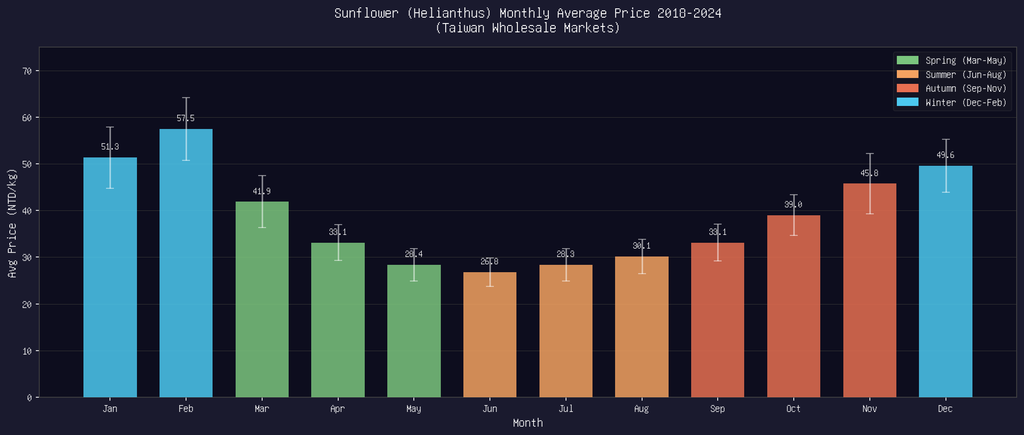

#### 圖表二：各市場價格時間序列（2018–2024）

呈現四個批發市場（台北、台中、彰化、屏東）的逐日價格走勢，白線為全市場月均價。可觀察到 COVID-19 期間（2020–2021）及通膨影響下的整體價格上揚。

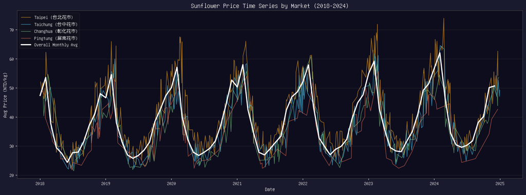

#### 圖表三：季節價格分布箱型圖

比較四季的批發價格分布（中位數、四分位距、極端值）。冬季中位數最高，夏季最低，印證了季節性供需結構。

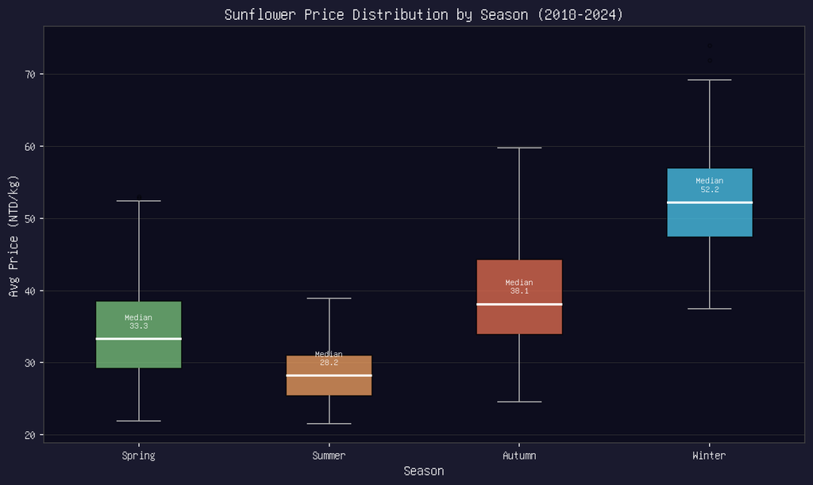

#### 圖表四：年度平均價格趨勢（2018–2024）

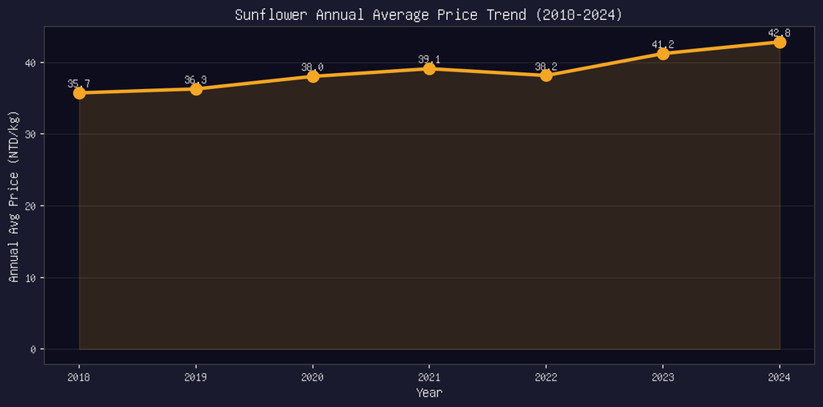

**📌 市場差異：** 台北花市均價最高（市場加成約 +8%），彰化及屏東花市因鄰近產地，均價較台北低約 7–10%。此差異反映物流成本與市場議價能力的地理分布。

## 結論與發現

[output not shown]

本研究確認台灣向日葵批發市場存在強烈的季節性價格波動，冬夏差距超過 85%。對花農而言，調整栽培時程以提高冬季或農曆年前供應量，可有效提升收益；對採購商而言，夏季（6–8月）為最佳採購時機。